# 第10章 机器学习神器：XGBoost与Light-GBM算法

- 基于GBDT算法的两种升级版Boosting算法--XGBoost和LightGBM算法

  这两种算法运行速度快, 预测准确度高, 且支持`并行操作`

  在商业实战中也有非常广泛的应用场景

## 10.1 XGBoost算法原理

- XGBoost算法是由华盛顿大学的陈天奇博士开发并开源的

  官方说明文档地址为https://xgboost.readthedocs.io
- 集成学习方法中的王牌算法

### 10.1.1 XGBoost算法的核心思想

- 在某种程度上可以说是GBDT算法的改良版, 两者在本质上都是利用了Boosting算法中拟合残差的思想

### 10.1.2 XGBoost算法的数学原理概述

- XGBoost算法的数学原理涉及非常多的高等数学和线性代数的知识, 这里只简单介绍一些核心知识
- 作为GBDT算法的高效实现, XGBoost算法在以下俩个方面进行了优化
  - `算法本身的优化`: XGBoost算法的损失函数, 除了本身的损失, 还`加上了正则化部分`, 可以防止过拟合, 泛化能力更强

    XGBoost算法的损失函数是`对误差部分做二阶泰勒展开`, 相较于GBDT算法的损失函数只对误差部分做负梯度(一阶泰勒)展开, 更加准确
  - `算法运行效率的优化`: 对每个弱学习器, 如决策树建立的过程做并行选择, 找到合适的子节点分裂特征和特征值, 从而提高运行效率

  算法本身的优化也是重难点, 其数学推导非常复杂, 详见陈天奇博士的相关论文

### 10.1.3 XGBoost算法的简单代码实现

```python
from xgboost import XGBClassifier

# XGBClassifier?
```

```python
import warnings

warnings.filterwarnings('ignore')

import numpy as np
```

```python
X = np.array([[1, 2], [3, 4], [5, 6], [7, 8], [9, 10]])
y = [0, 0, 0, 1, 1]

model = XGBClassifier()
model.fit(X, y)

print(model.predict([[5, 5]]))
```

```
[0]
```

XGBoost分类模型的特征变量不支持直接输入list列表类型的数据，可以传入array数组格式的数据或者DataFrame二维表格格式的数据

```python
from xgboost import XGBRegressor
X = [[1, 2], [3, 4], [5, 6], [7, 8], [9, 10]]
y = [1, 2, 3, 4, 5]

model = XGBRegressor()
model.fit(X, y)

print(model.predict([[5, 5]]))
```

```
[2.9999917]
```

## 10.2 XGBoost算法案例实战1: 金融反欺诈模型

### 10.2.2 模型搭建

```python
import pandas as pd
df = pd.read_excel('信用卡交易数据.xlsx')
df.head()
```

|  | 换设备次数 | 支付失败次数 | 换IP次数 | 换IP国次数 | 交易金额 | 欺诈标签 |
| --- | --- | --- | --- | --- | --- | --- |
| 0 | 0 | 11 | 3 | 5 | 28836 | 1 |
| 1 | 5 | 6 | 1 | 4 | 21966 | 1 |
| 2 | 6 | 2 | 0 | 0 | 18199 | 1 |
| 3 | 5 | 8 | 2 | 2 | 24803 | 1 |
| 4 | 7 | 10 | 5 | 0 | 26277 | 1 |

```python
# 通过如下代码将特征变量和目标变量单独提取出来，代码如下：
X = df.drop(columns='欺诈标签')
y = df['欺诈标签']
```

```python
# 提取完特征变量后，通过如下代码将数据拆分为训练集及测试集：
from sklearn.model_selection import train_test_split
X_train, X_test, y_train, y_test = train_test_split(X, y, test_size=0.2, random_state=123)
```

```python
# 划分为训练集和测试集之后，就可以引入XGBoost分类器进行模型训练了，代码如下：
from xgboost import XGBClassifier
clf = XGBClassifier(n_estimators=100, learning_rate=0.05)
clf.fit(X_train, y_train)
```

```
XGBClassifier(base_score=None, booster=None, callbacks=None,
              colsample_bylevel=None, colsample_bynode=None,
              colsample_bytree=None, device=None, early_stopping_rounds=None,
              enable_categorical=False, eval_metric=None, feature_types=None,
              feature_weights=None, gamma=None, grow_policy=None,
              importance_type=None, interaction_constraints=None,
              learning_rate=0.05, max_bin=None, max_cat_threshold=None,
              max_cat_to_onehot=None, max_delta_step=None, max_depth=None,
              max_leaves=None, min_child_weight=None, missing=nan,
              monotone_constraints=None, multi_strategy=None, n_estimators=100,
              n_jobs=None, num_parallel_tree=None, ...)
```

```python
# 模型搭建完毕后，通过如下代码预测测试集数据：
y_pred = clf.predict(X_test)

y_pred  # 打印预测结果
```

```
array([0, 1, 1, 0, 0, 0, 1, 0, 0, 0, 1, 1, 1, 1, 1, 0, 0, 0, 0, 0, 1, 1,
       1, 0, 0, 0, 0, 0, 0, 1, 0, 1, 0, 1, 0, 0, 1, 1, 1, 0, 0, 1, 0, 0,
       0, 0, 1, 0, 0, 0, 1, 0, 0, 0, 1, 1, 0, 1, 0, 0, 0, 0, 1, 0, 1, 0,
       0, 0, 0, 1, 1, 0, 0, 0, 0, 0, 0, 0, 1, 0, 0, 0, 0, 0, 0, 1, 0, 0,
       0, 1, 0, 0, 0, 1, 1, 0, 0, 0, 0, 0, 0, 0, 0, 0, 0, 0, 1, 0, 0, 1,
       0, 0, 1, 0, 1, 0, 0, 0, 1, 0, 0, 0, 0, 0, 0, 1, 0, 0, 1, 1, 0, 0,
       0, 0, 0, 0, 0, 1, 0, 0, 1, 0, 0, 1, 1, 0, 0, 1, 0, 1, 0, 0, 0, 0,
       1, 0, 1, 1, 1, 0, 1, 0, 1, 1, 1, 0, 0, 0, 0, 0, 0, 0, 0, 0, 0, 0,
       0, 1, 0, 0, 0, 1, 0, 0, 1, 0, 0, 1, 0, 0, 1, 0, 0, 0, 0, 0, 1, 0,
       1, 1])
```

```python
# 通过和之前章节类似的代码，我们可以将预测值和实际值进行对比：
a = pd.DataFrame()  # 创建一个空DataFrame
a['预测值'] = list(y_pred)
a['实际值'] = list(y_test)
a.head()
```

|  | 预测值 | 实际值 |
| --- | --- | --- |
| 0 | 0 | 1 |
| 1 | 1 | 1 |
| 2 | 1 | 1 |
| 3 | 0 | 0 |
| 4 | 0 | 1 |

```python
# 可以看到此时前五项的预测准确度为60%，如果想看所有测试集数据的预测准确度，可以使用如下代码：
from sklearn.metrics import accuracy_score
score = accuracy_score(y_pred, y_test)
score
```

```
0.875
```

```python
# 还可以通过XGBClassifier()自带的score()函数来查看模型预测的准确度评分，代码如下，获得的结果同样是0.875。
clf.score(X_test, y_test)
```

```
0.875
```

```python
# XGBClassifier分类器本质预测的并不是准确的0或1的分类，而是预测其属于某一分类的概率，可以通过predict_proba()函数查看预测属于各个分类的概率，代码如下：
y_pred_proba = clf.predict_proba(X_test)
print(y_pred_proba[0:5])  # 查看前5个预测的概率
```

```
[[0.8706477  0.12935229]
 [0.02221072 0.9777893 ]
 [0.00936866 0.99063134]
 [0.8994155  0.10058449]
 [0.8518455  0.14815451]]
```

```python
# 此时的y_pred_proba是个二维数组，其中第一列为分类为0（也即非欺诈）的概率，第二列为分类为1（也即欺诈）的概率，因此如果想查看欺诈（分类为1）的概率，可采用如下代码：
# y_pred_proba[:,1]  # 分类为1的概率
```

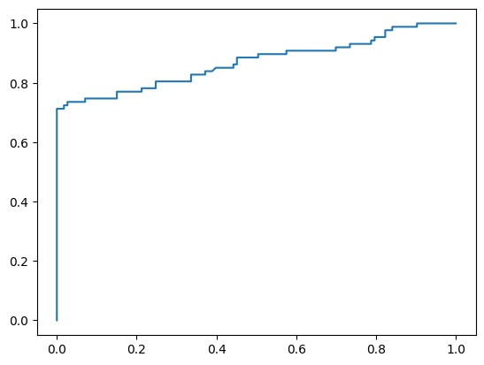

```python
# 下面我们利用4.3节相关代码绘制ROC曲线来评估模型预测的效果：
from sklearn.metrics import roc_curve
fpr, tpr, thres = roc_curve(y_test, y_pred_proba[:,1])
import matplotlib.pyplot as plt
plt.plot(fpr, tpr)
plt.show()
```

```python
# 通过如下代码求出模型的AUC值：
from sklearn.metrics import roc_auc_score
score = roc_auc_score(y_test, y_pred_proba[:,1])

score
```

```
0.8690367205777643
```

```python
# 通过如下5.2.2节特征重要性相关知识点进行整理，方便结果呈现，代码如下：
features = X.columns  # 获取特征名称
importances = clf.feature_importances_  # 获取特征重要性

# 通过二维表格形式显示
importances_df = pd.DataFrame()
importances_df['特征名称'] = features
importances_df['特征重要性'] = importances
importances_df.sort_values('特征重要性', ascending=False)
```

|  | 特征名称 | 特征重要性 |
| --- | --- | --- |
| 0 | 换设备次数 | 0.395957 |
| 3 | 换IP国次数 | 0.348460 |
| 1 | 支付失败次数 | 0.188594 |
| 2 | 换IP次数 | 0.042056 |
| 4 | 交易金额 | 0.024933 |

```python
from sklearn.model_selection import GridSearchCV
parameters = {'max_depth': [1, 3, 5], 'n_estimators': [50, 100, 150], 'learning_rate': [0.01, 0.05, 0.1, 0.2]}  # 指定模型中参数的范围
clf = XGBClassifier()  # 构建模型
grid_search = GridSearchCV(clf, parameters, scoring='roc_auc', cv=5)
```

```python
# 下面我们将数据传入网格搜索模型并输出参数最优值：
grid_search.fit(X_train, y_train)  # 传入数据
grid_search.best_params_  # 输出参数的最优值
```

```
{'learning_rate': 0.05, 'max_depth': 1, 'n_estimators': 100}
```

```python
# 下面我们根据新的参数建模，首先重新搭建XGBoost分类器，并将训练集数据传入其中：
clf = XGBClassifier(max_depth=1, n_estimators=100, learning_rate=0.05)
clf.fit(X_train, y_train)
```

```
XGBClassifier(base_score=None, booster=None, callbacks=None,
              colsample_bylevel=None, colsample_bynode=None,
              colsample_bytree=None, device=None, early_stopping_rounds=None,
              enable_categorical=False, eval_metric=None, feature_types=None,
              feature_weights=None, gamma=None, grow_policy=None,
              importance_type=None, interaction_constraints=None,
              learning_rate=0.05, max_bin=None, max_cat_threshold=None,
              max_cat_to_onehot=None, max_delta_step=None, max_depth=1,
              max_leaves=None, min_child_weight=None, missing=nan,
              monotone_constraints=None, multi_strategy=None, n_estimators=100,
              n_jobs=None, num_parallel_tree=None, ...)
```

```python
# 因为是通过ROC曲线的AUC评分作为模型评价准则来进行参数调优的，因此通过如下代码\来查看新的AUC值：
y_pred_proba = clf.predict_proba(X_test)
from sklearn.metrics import roc_auc_score
score = roc_auc_score(y_test, y_pred_proba[:,1])
print(score)
```

```
0.8563218390804598
```

出现这种情况的原因是因为交叉验证，我们来简单回顾下5.3节K折交叉验证的思路：它是将原来的测试数据分为K份（这里cv=5，即5份），然后在这K份数据中，选K-1份作为训练数据，剩下的1份作为测试数据，训练K次，获得K个的ROC曲线下的AUC值，然后将K个AUC值取平均，取AUC值的均值为最大情况下的参数为模型的最优参数。注意这里AUC值的获取是基于训练集数据，只不过是将训练集数据中的1/K作为测试集数据，这里的测试集数据并不是真正的测试集数据y_test，这也是为什么参数调优后结果反而不如不调优的结果的原因。实际应用中，通常不太会出现调参结果不如不调参的结果，出现这种情况某种程度也是因为数据量较小的原因（像本案例为1000条数据）。其他关于参数调优的其他一些注意点请参考5.3节，这里不再赘述

### 补充知识点: XGBoost分类模型的常见超参数

- XGBoost分类模型的常见超参数

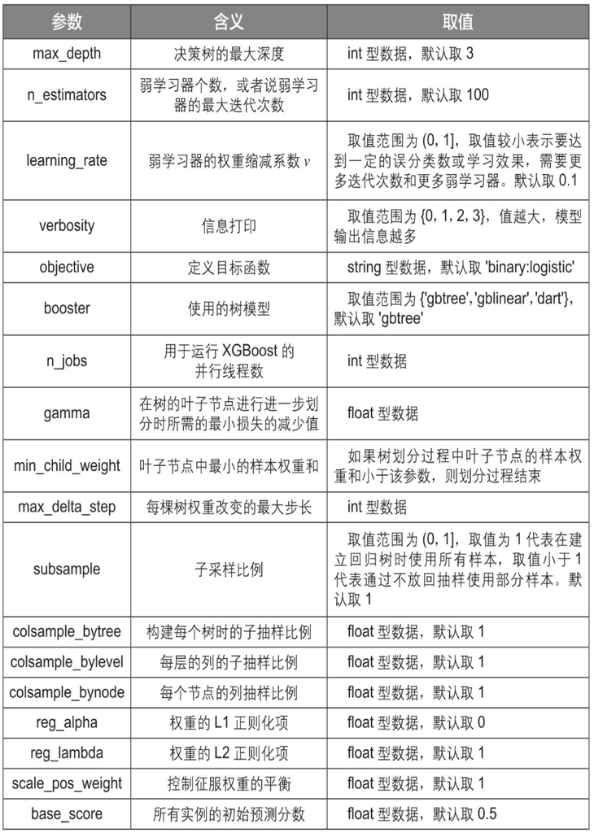

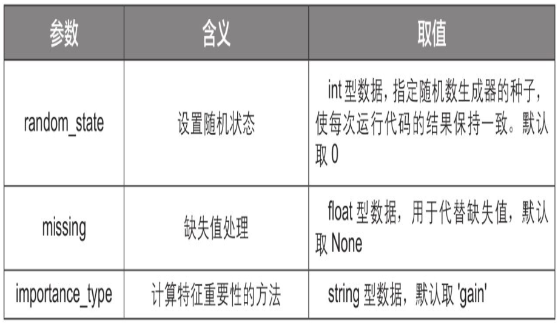

- XGBoost回归模型的参数大多数与分类模型一致, 略有不同的是objective参数在回归问题中取值为'reg:linear', 而在二分类问题中一般取值为'binary:logistic', 在多分类问题中一般取值为'multi:softmax'

  不过当选择XGBoost回归模型时, 该参数会自动切换, 所以也无需手动调整

## 10.3 XGBoost算法案例实战2: 信用评分卡模型

- 为了对比, 这一节还会额外使用多元线性回归模型(第3章)和GBDT回归模型(第9章)进行模型搭建

### 10.3.1 案例背景

- 为了降低不良贷款率，保障自身资金安全，提高风险控制水平，银行等金融机构会根据客户的信用历史资料构建信用评分卡模型给客户评分

  根据客户的信用得分，可以预估客户按时还款的可能性，并据此决定是否发放贷款及贷款的额度和利率

### 10.3.2 多元线性回归模型

```python
import pandas as pd
df = pd.read_excel('信用评分卡模型.xlsx')
df.head()
```

|  | 月收入 | 年龄 | 性别 | 历史授信额度 | 历史违约次数 | 信用评分 |
| --- | --- | --- | --- | --- | --- | --- |
| 0 | 7783 | 29 | 0 | 32274 | 3 | 73 |
| 1 | 7836 | 40 | 1 | 6681 | 4 | 72 |
| 2 | 6398 | 25 | 0 | 26038 | 2 | 74 |
| 3 | 6483 | 23 | 1 | 24584 | 4 | 65 |
| 4 | 5167 | 23 | 1 | 6710 | 3 | 73 |

```python
# 通过如下代码将特征变量和目标变量单独提取出来，代码如下：
X = df.drop(columns='信用评分')
Y = df['信用评分']
```

```python
# 从Scikit-Learn库中引入LinearRegression()模型进行模型训练，代码如下：
from sklearn.linear_model import LinearRegression
model = LinearRegression()
model.fit(X,Y)
```

```
LinearRegression()
```

```python
# 4.线性回归方程构造
print('各系数为:' + str(model.coef_))
print('常数项系数k0为:' + str(model.intercept_))
```

```
各系数为:[ 5.58658996e-04  1.62842002e-01  2.18430276e-01  6.69996665e-05
 -1.51063940e+00]
常数项系数k0为:67.16686603853304
```

```python
# 利用3.2节模型评估的方法对此多元线性回归模型进行评估，代码如下：
import statsmodels.api as sm
X2 = sm.add_constant(X)
est = sm.OLS(Y, X2).fit()
est.summary()
```

OLS Regression Results

| Dep. Variable: | 信用评分 | R-squared: | 0.629 |
| --- | --- | --- | --- |
| Model: | OLS | Adj. R-squared: | 0.628 |
| Method: | Least Squares | F-statistic: | 337.6 |
| Date: | Tue, 25 Mar 2025 | Prob (F-statistic): | 2.32e-211 |
| Time: | 11:16:52 | Log-Likelihood: | -2969.8 |
| No. Observations: | 1000 | AIC: | 5952. |
| Df Residuals: | 994 | BIC: | 5981. |
| Df Model: | 5 |  |  |
| Covariance Type: | nonrobust |  |  |

|  | coef | std err | t | P>\|t\| | [0.025 | 0.975] |
| --- | --- | --- | --- | --- | --- | --- |
| const | 67.1669 | 1.121 | 59.906 | 0.000 | 64.967 | 69.367 |
| 月收入 | 0.0006 | 8.29e-05 | 6.735 | 0.000 | 0.000 | 0.001 |
| 年龄 | 0.1628 | 0.022 | 7.420 | 0.000 | 0.120 | 0.206 |
| 性别 | 0.2184 | 0.299 | 0.730 | 0.466 | -0.369 | 0.806 |
| 历史授信额度 | 6.7e-05 | 7.78e-06 | 8.609 | 0.000 | 5.17e-05 | 8.23e-05 |
| 历史违约次数 | -1.5106 | 0.140 | -10.811 | 0.000 | -1.785 | -1.236 |

| Omnibus: | 13.180 | Durbin-Watson: | 1.996 |
| --- | --- | --- | --- |
| Prob(Omnibus): | 0.001 | Jarque-Bera (JB): | 12.534 |
| Skew: | -0.236 | Prob(JB): | 0.00190 |
| Kurtosis: | 2.721 | Cond. No. | 4.27e+05 |

Notes:  
[1] Standard Errors assume that the covariance matrix of the errors is correctly specified.  
[2] The condition number is large, 4.27e+05. This might indicate that there are  
strong multicollinearity or other numerical problems.

- 可以看到模型整体的R-squared为0.629，Adj. R-Squared为0.628，整体拟合效果一般，可能是因为数据量偏少的原因
- 同时我们再来观察P值，可以发现大部分特征变量的P值都较小（小于0.05），的确是和目标变量：信用评分显著相关，而性别这一特征变量的P值达到了0.466，即与目标变量没有显著相关性，这个也的确符合经验认知，所以在多元线性回归模型中，我们其实可以把性别这一特征变量舍去

### 10.3.3 GBDT回归模型

```python
# 这里使用第九章讲过的GBDT回归模型同样来做一下回归分析，首先读取1000条信用卡客户的数据并划分特征变量和目标变量，这部分代码和上面线性回归的代码是一样的。
# 1.读取数据
import pandas as pd
df = pd.read_excel('信用评分卡模型.xlsx')
# 2.提取特征变量和目标变量
X = df.drop(columns='信用评分')
y = df['信用评分']
```

```python
# 通过如下代码划分训练集和测试集数据：
from sklearn.model_selection import train_test_split
X_train, X_test, y_train, y_test = train_test_split(X, y, test_size=0.2, random_state=123)
```

```python
# 划分训练集和测试集完成后，就可以从Scikit-Learn库中引入GBDT模型进行模型训练了，代码如下：
from sklearn.ensemble import GradientBoostingRegressor
model = GradientBoostingRegressor(random_state=123)  # 使用默认参数
model.fit(X_train, y_train)
```

```
GradientBoostingRegressor(random_state=123)
```

```python
# 模型搭建完毕后，通过如下代码预测测试集数据：
y_pred = model.predict(X_test)
print(y_pred[0:10])
```

```
[70.77631652 71.40032104 73.73465155 84.52533945 71.09188294 84.9327599
 73.72232388 83.44560704 82.61221486 84.86927209]
```

```python
# 通过和之前章节类似的代码，我们可以将预测值和实际值进行对比：
a = pd.DataFrame()  # 创建一个空DataFrame
a['预测值'] = list(y_pred)
a['实际值'] = list(y_test)
a.head()
```

|  | 预测值 | 实际值 |
| --- | --- | --- |
| 0 | 70.776317 | 79 |
| 1 | 71.400321 | 80 |
| 2 | 73.734652 | 62 |
| 3 | 84.525339 | 89 |
| 4 | 71.091883 | 80 |

```python
# 因为GradientBoostingRegressor()是一个回归模型，所以我们通过查看其R-squared值来评判模型的拟合效果：
from sklearn.metrics import r2_score
r2 = r2_score(y_test, model.predict(X_test))
print(r2)
```

```
0.6725388975816635
```

```python
# 我们还可以通过GradientBoostingRegressor()自带的score()函数来查看模型预测的效果：
model.score(X_test, y_test)
```

```
0.6725388975816635
```